# R Notebook

```r
library(tidyverse)
library(tidyr)
library(DBI)
library(odbc)
```

```r
con <- dbConnect(odbc::odbc(), "akfin", UID="jwatson", PWD= rstudioapi::askForPassword("Enter AKFIN Password"))

dbFetch(dbSendQuery(con,"SELECT a.psc_fishery_code,
                                                a.year,
                                                a.el_report_id,
                                                a.trip_target_date,
                                                r.landing_date,
                                                r.tender_vessel_adfg_number,
                                                r.port_code,
                                                r.observers_onboard,
                                                a.processing_sector,
                                                a.catch_activity_date,
                                                a.catcher_vessel_id,
                                                a.catch_report_type_code,
                                                a.data_source_type_code,
                                                a.management_program_code,
                                                a.agency_gear_code,
                                                a.adfg_stat_area_code,
                                                a.reporting_area_code,
                                                a.pscnq_estimate,
                                                a.species_count,
                                                a.rate_precedence,
                                                a.rate,
                                                a.retained_gf_basis_weight AS RETAINED_GF_WEIGHT,
                                                a.total_gf_basis_weight,
                                                a.rate*a.total_gf_basis_weight as manual_CALC_example,
                                                a.trip_target_code,
                                                a.species_group_code,
                                                a.fmp_sub_area_code

                                                FROM akr.v_cas_txn_primary_psc a
                                                LEFT JOIN akr.V_ELLR_REPORT r
                                                on r.report_id=a.el_report_id

                                                where a.species_group_code='CHNK'
                                                and a.FMP_SUB_AREA_CODE in ('BS','GOA','AI')
                                                and a.agency_gear_code in ('NPT','PTR')")) %>%
  rename_all(tolower) %>%
  saveRDS(file="Chinook_Rates_add_species.RDS")

#  Pull in vessel info
dbFetch(dbSendQuery(con,"SELECT distinct catcher_vessel_id,ves_akr_length,year from council.comprehensive_blend_ca")) %>%
  rename_all(tolower) %>%
  mutate(year=as.numeric(year)) %>%
  saveRDS(file="Catcher_vessel_id_length.RDS")

#  Pull in look up table of trip target codes
dbFetch(dbSendQuery(con,"SELECT distinct trip_target_code,trip_target_name from council.comprehensive_blend_ca")) %>%
  rename_all(tolower) %>%
  saveRDS(file="Trip_Target_Codes.RDS")
```

Merge and edit the trip target codes, round calculated fields to reduce file size, and create a pollock/non-target field.

```r
data <- readRDS("Chinook_Rates_add_species.RDS")
vessels <- readRDS("Catcher_vessel_id_length.RDS")
targets <- readRDS("Trip_Target_Codes.RDS")

data %>%
  left_join(vessels) %>%
  left_join(targets) %>%
  mutate(pscnq_estimate=round(pscnq_estimate,3),
         rate=round(rate,4),
         retained_gf_weight=round(retained_gf_weight,3),
         total_gf_basis_weight=round(total_gf_basis_weight,3),
         manual_calc_example=round(manual_calc_example,3),
         target=ifelse(trip_target_code%in%c("B","P"),"pollock","non-pollock"),
         trip_target_date=as.Date(trip_target_date),
         landing_date=as.Date(landing_date)) %>%
  saveRDS(file="Chinooky_Rates_merged.RDS")
```

Now read in and explore the data. I am going to create some shorter column names for ease of using the data as well.

```r
data <- readRDS("Chinooky_Rates_merged.RDS") %>%
  dplyr::select(-psc_fishery_code,
                sector=processing_sector,
                cv_id=catcher_vessel_id,
                mgmt_code=management_program_code,
                gear=agency_gear_code,
                statarea=adfg_stat_area_code,
                nmfsarea=reporting_area_code,
                vlength=ves_akr_length,
                fmp_area=fmp_sub_area_code)

head(data)
```

|  | year | el_report_id | trip_target_date | landing_date | tender_vessel_adfg_number | port_code | observers_onboard | sector | catch_activity_date | cv_id | catch_report_type_code | data_source_type_code | mgmt_code | gear | statarea | nmfsarea | pscnq_estimate | species_count | rate_precedence | rate | retained_gf_weight | total_gf_basis_weight | manual_calc_example | trip_target_code | species_group_code | fmp_area | vlength | trip_target_name | target |
| --- | --- | --- | --- | --- | --- | --- | --- | --- | --- | --- | --- | --- | --- | --- | --- | --- | --- | --- | --- | --- | --- | --- | --- | --- | --- | --- | --- | --- | --- |
| 1 | 2009 | NA | 2009-07-18 |  | NA | NA | NA | M | 2009-07-18 | 421 | OBS | EST | AFA | PTR | 705630 | 521 | 0.023 | 0.02 | 50 | 0.0006 | NA | 37.611 | 0.023 | P | CHNK | BS | 110 | Pollock - midwater | pollock |
| 2 | 2009 | NA | 2009-01-31 |  | NA | NA | NA | CP | 2009-01-31 | 4063 | OBS | EST | AFA | PTR | 635530 | 509 | 2.126 | 2.13 | 50 | 0.0491 | NA | 43.284 | 2.126 | B | CHNK | BS | 341 | Pollock - bottom | pollock |
| 3 | 2009 | NA | 2009-10-31 |  | NA | NA | NA | CP | 2009-10-31 | 2924 | OBS | EST | OA | NPT | 435931 | 640 | 6.078 | 6.08 | 50 | 0.8891 | NA | 6.836 | 6.078 | K | CHNK | GOA | 107 | Rockfish | non-pollock |
| 4 | 2009 | NA | 2009-04-11 |  | NA | NA | NA | CP | 2009-04-11 | 2800 | OBS | EST | OA | NPT | 565534 | 620 | 9.292 | 9.29 | 50 | 0.2210 | NA | 42.040 | 9.292 | X | CHNK | GOA | 185 | Rex Sole - GOA | non-pollock |
| 5 | 2009 | NA | 2009-01-31 |  | NA | NA | NA | CP | 2009-01-31 | 3671 | OBS | EST | AFA | PTR | 635530 | 509 | 2.556 | 2.56 | 50 | 0.0311 | NA | 82.116 | 2.556 | P | CHNK | BS | 275 | Pollock - midwater | pollock |
| 6 | 2009 | NA | 2009-09-12 |  | NA | NA | NA | CP | 2009-09-12 | 3261 | OBS | EST | AFA | PTR | 776030 | 524 | 0.280 | 0.28 | 50 | 0.0029 | NA | 97.562 | 0.280 | P | CHNK | BS | 341 | Pollock - midwater | pollock |

What are the different trip target codes?

```r
data %>%
  distinct(trip_target_code,trip_target_name) %>%
  data.frame
```

| trip_target_code | trip_target_name |
| --- | --- |
| P | Pollock - midwater |
| B | Pollock - bottom |
| K | Rockfish |
| X | Rex Sole - GOA |
| C | Pacific Cod |
| W | Arrowtooth Flounder |
| H | Shallow Water Flatfish - GOA |
| L | Flathead Sole |
| R | Rock Sole - BSAI |
| Y | Yellowfin Sole - BSAI |

[output cut: 8 more lines]

So I think there are a couple of key pieces to what we’re interested in here. Note that there are a few places where the field descriptions will say “Null if the amount was reported”. By “reported” I believe they mean, directly observed. And by “null” I believe that they mean “Zero”. I have a query out to Cathy Tide to see if she can clarify both of those points. Some of the descriptions below are a little redundant because I pulled the descriptions from several different tables in different DB schemas.

**pscnq_estimate** The estimated amount of prohibited species catch (PSC), before any adjustments for mortality rate (PSCNQ_ESTIMATE = RATE * GROUNDFISH_BASIS_WEIGHT). Null if the PSC species amount was reported.

**rate** Calculated rate of discards for non-CDQ hauls with PSC bycatch; Counts for chinook; depends on which precedence level is used If the species amount is estimated, the rate used to calculate the species estimate (RATE * GROUNDFISH_BASIS_WEIGHT = PSCNQ_ESTIMATE). Null if the amount was reported. Unit is “# of salmon / mt groundfish”

**rate_precedence** If I understand correctly, the rate_precedence field is what determines the psc_rate (i.e., multiplier) for a given vessel, sector, fleet, time period, etc. From Council.comprehensive_psc table in AKFIN, we get this description of rate_precedence: “Relative priority of a prohibited species / non-quota rate record: 50 = vessel-specific, 45 = coop-specific, 40 = processing sector, 30 = 3-week moving average, 25 = 3-month moving average, 20 = FMP area.”

From akr.v_cas_txn_primary_psc, we get this description of rate_precedence: “If the species amount is estimated, the precendence (e.g. 50, 40, 30, 20, etc.) of the rate factor of the rate used to calculate the estimate. Null if the amount is reported.”

That said, I don’t think we’ll actually need this but it’s helpful to get a better sense of how the multipliers (rate) work.

**species_count** The amount of the species in number of animals (Salmon and Crab). Null if the species group is measured by weight (Halibut and Herring).

**RETAINED_GF_WEIGHT** The retained basis weight is the sum of weights of all retained groundfish (excluding PSC and non-target species) on the catch report. A species group is considered to be a groundfish species if the GROUNDFISH_FLAG on the associated SPECIES_GROUP record = ‘Y’.

**total_gf_basis_weight** The total basis weight is the sum of weights of all retained groundfish and estimated discards of groundfish (excluding PSC and non-target species) on the catch report. A species group is considered to be a groundfish species if the GROUNDFISH_FLAG on the associated SPECIES_GROUP record = ‘Y’.

Note that this is the field by which the rate is multiplied to get our Chinook estimate when there is no observer record.

**el_report_id** This just tells us if the data came from an observer or from an electronic trip reporting record (ie., no observer). So we don’t really need this but if it’s NA then it was likely an observed trip (when they are observed, they must not have to file an eLandings report). But I think this is relevant because it tells the database to use a certain rate precendence code and to estimate the bycatch.

**catch_report_type_Code** Character code that identifies the type of catch report from which this transaction originated: CDQ = CDQ Catch Report, ELLR = eLandings Landing Report, ELPR = eLandings Production Report, OBS = Observer haul, SLOG = Shoreside Logbook, SWPR = Shoreside Weekly Production Report, VWPR = Vessel Weekly Production Report.

**data_source_type_code** Character code that identifies the type of species record from which this transaction originated: View V_CAS_DATA_SOURCE for a list of possible values.

**observers_onboard** Number of state, federal, or authorized contractor fisheries observers on board the vessel.

**tender_vessel_adfg_number** Identifies whether a vessel delivered to a tender. Deliveries to tenders do not get sampled for CWTs at all so instead of a 1/10 fraction for these, it would just be a zero. These should also only occur when catch_report_type_code is ELLR. ALso, looks like this field isn’t filled out prior to 2008 :(.

```r
data %>%
  filter(fmp_area=="BS") %>%
  group_by(rate_precedence,year) %>%
  tally() %>%
  spread(year,n)
```

| rate_precedence | 2003 | 2004 | 2005 | 2006 | 2007 | 2008 | 2009 | 2010 | 2011 | 2012 | 2013 | 2014 | 2015 | 2016 | 2017 | 2018 | 2019 | 2020 |
| --- | --- | --- | --- | --- | --- | --- | --- | --- | --- | --- | --- | --- | --- | --- | --- | --- | --- | --- |
| 0 | NA | 780 | 446 | 400 | 867 | 138 | 95 | NA | 12988 | 11003 | 10844 | 11135 | 10729 | 10444 | 10689 | 10852 | 10981 | 4422 |
| 20 | NA | NA | NA | NA | NA | NA | NA | NA | NA | NA | NA | NA | NA | NA | 2 | 5 | NA | NA |
| 25 | 11 | 15 | 19 | 25 | 14 | 19 | 15 | 47 | 8 | 19 | 15 | 7 | 39 | 50 | 22 | 10 | 8 | NA |
| 30 | 10 | NA | 3 | 8 | 3 | 8 | 5 | 6 | 5 | 5 | 2 | NA | 4 | NA | NA | NA | NA | NA |
| 40 | 1258 | 1358 | 1384 | 1086 | 1193 | 806 | 631 | 991 | 346 | 247 | 184 | 171 | 287 | 374 | 224 | 226 | 154 | 114 |
| 50 | 8332 | 8749 | 8696 | 7206 | 8020 | 4111 | 3150 | 18654 | 12148 | 11721 | 13584 | 13892 | 13777 | 15776 | 14299 | 16025 | 17377 | 6609 |

```r
data %>%
  filter(fmp_area=="GOA") %>%
  group_by(rate_precedence,year) %>%
  tally() %>%
  spread(year,n)
```

| rate_precedence | 2003 | 2004 | 2005 | 2006 | 2007 | 2008 | 2009 | 2010 | 2011 | 2012 | 2013 | 2014 | 2015 | 2016 | 2017 | 2018 | 2019 | 2020 |
| --- | --- | --- | --- | --- | --- | --- | --- | --- | --- | --- | --- | --- | --- | --- | --- | --- | --- | --- |
| 0 | NA | NA | NA | NA | NA | NA | NA | NA | NA | NA | NA | NA | NA | NA | NA | NA | NA | 74 |
| 20 | 3 | 12 | 1 | 12 | NA | 2 | 2 | 33 | 14 | 5 | 12 | 36 | 33 | 38 | 123 | 59 | 25 | 29 |
| 25 | 82 | 138 | 107 | 149 | 232 | 336 | 261 | 507 | 578 | 332 | 262 | 429 | 250 | 304 | 251 | 116 | 197 | 147 |
| 30 | 7 | 5 | NA | 1 | 4 | 8 | 4 | 19 | 80 | 202 | 46 | 78 | 12 | 1 | NA | 11 | NA | NA |
| 40 | 825 | 779 | 993 | 1004 | 529 | 469 | 447 | 1292 | 1152 | 1435 | 1511 | 2163 | 2246 | 2362 | 1977 | 1761 | 1389 | 572 |
| 45 | NA | NA | NA | NA | NA | 4 | 1 | 1 | 2 | 9 | 18 | 4 | 19 | 6 | 2 | 8 | 14 | 2 |
| 50 | 766 | 295 | 215 | 230 | 471 | 334 | 345 | 2110 | 2032 | 2268 | 2401 | 3004 | 2825 | 2821 | 3015 | 2266 | 2617 | 478 |

There are some **rate** values that are greater than 1 but they account for < 0.05% of all records. Below is a distribution of the rates between 0 and 1.

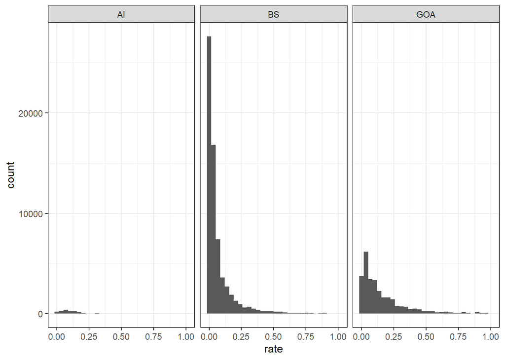

```r
data %>%
  filter(rate>0 & rate<1) %>%
  ggplot(aes(rate)) +
  geom_histogram() +
  facet_wrap(~fmp_area) +
  theme_bw()
```

The official reported PSC statistics from the AK Region are here: https://www.fisheries.noaa.gov/sites/default/files/akro/goasalmonmort2020.html While our numbers don’t match theirs exactly, that’s not totally surprising, because even these official tallies change period (including historical data). Buuuut, we get really close.

We see, for example that

```r
data %>%
  filter(target=="pollock" & fmp_area%in%c("GOA")) %>%
  group_by(year) %>%
  summarise(est_count=sum(pscnq_estimate,na.rm=TRUE),
            spp_count=sum(species_count,na.rm=TRUE)) %>%
  data.frame
```

| year | est_count | spp_count |
| --- | --- | --- |
| 2003 | 4399.894 | 4399.920 |
| 2004 | 13151.969 | 13152.020 |
| 2005 | 27926.821 | 27926.730 |
| 2006 | 15705.544 | 15705.640 |
| 2007 | 35095.662 | 35095.680 |
| 2008 | 10745.604 | 10745.540 |
| 2009 | 3188.348 | 3188.320 |
| 2010 | 44441.852 | 44441.854 |
| 2011 | 12655.026 | 12655.046 |
| 2012 | 16382.670 | 16382.662 |

[output cut: 8 more lines]

If we compare to the published BSAI data we get really close (below) https://www.fisheries.noaa.gov/sites/default/files/akro/chinook_salmon_mortality2020.html

```r
data %>%
  filter(target=="pollock" & fmp_area%in%c("BS","AI")) %>%
  group_by(year) %>%
  summarise(est_count=sum(pscnq_estimate,na.rm=TRUE),
            spp_count=sum(species_count,na.rm=TRUE)) %>%
  data.frame
```

| year | est_count | spp_count |
| --- | --- | --- |
| 2003 | 43095.699 | 43095.740 |
| 2004 | 48796.708 | 51748.460 |
| 2005 | 66251.311 | 68169.150 |
| 2006 | 81015.380 | 82753.210 |
| 2007 | 116575.206 | 122201.280 |
| 2008 | 20666.485 | 21306.670 |
| 2009 | 12131.849 | 12578.870 |
| 2010 | 9848.114 | 9848.085 |
| 2011 | 0.000 | 25499.000 |
| 2012 | 0.000 | 11343.000 |

[output cut: 8 more lines]

Let’s look at the Rockfish Pilot Program.

```r
data %>%
  filter(mgmt_code=="RPP" & nmfsarea%in%c(610,620,630)) %>%
  group_by(year) %>%
  summarise(est_count=sum(pscnq_estimate,na.rm=TRUE),
            spp_count=sum(species_count,na.rm=TRUE)) %>%
  data.frame
```

| year | est_count | spp_count |
| --- | --- | --- |
| 2007 | 509.601 | 509.6200 |
| 2008 | 1688.941 | 1688.9300 |
| 2009 | 860.194 | 860.2000 |
| 2010 | 1246.492 | 1246.4930 |
| 2011 | 699.389 | 699.3891 |
| 2012 | 1238.610 | 1238.6108 |
| 2013 | 2263.589 | 2263.5913 |
| 2014 | 649.180 | 649.1790 |
| 2015 | 1854.967 | 1854.9668 |
| 2016 | 392.711 | 392.7108 |

[output cut: 4 more lines]

```r
con <- dbConnect(odbc::odbc(), "akfin", UID="jwatson", PWD= rstudioapi::askForPassword("Enter AKFIN Password"))

dbFetch(dbSendQuery(con,"select a.haul_date,
a.akr_gear_code,
a.target_fishery_code,
a.pscnq_processing_sector,
a.sample_number,
a.sample_weight,
a.extrapolated_weight,
a.extrapolated_number,
a.ves_akr_cg_num,
a.ves_AKR_length,
a.reporting_area_code
from council.comprehensive_obs a
where a.species_group_code='CHNK'
and a.akr_gear_code in ('PTR','NPT')")) %>%
  rename_all(tolower) %>%
  saveRDS(file="Chinook_extrapolated_weight.RDS")
```

We talked about an issue with the “observers onboard” field in the “data” object described above. The problem is figuring out how many trips were actually observed. So I have gone through the comprehensive_obs table in AKFIN, which includes haul information for each trip. Unfortunately, the observer program has been recording “hauls” since like 1991 but they didn’t start recording “trip” data until like 2007. So, we have to piece together trips prior to then. I am using a couple of fields to do this. The field “cruise” describes an observer’s deployment. But on a particular cruise, an observer could be deployed for several months and go on many trips and on multiple vessels. So I also add a field “obs_vessel_id” which tracks a particular observer. On a particular “cruise”+“obs_vessel_id” combo, there will be many hauls. For each trip, an observer should label each haul, its date, and the date that fishing started on a particular trip. So if we use “cruise”+“obs_vessel_id”+“fishing vessel”+“fishing_start_date”, this should give us a unique identifier for each trip. For most trips, this will give us a bunch of duplicates (one row for each haul). So we can remove the duplicates and that should give us one row for each trip.

```r
con <- dbConnect(odbc::odbc(), "akfin", UID="jwatson", PWD= rstudioapi::askForPassword("Enter AKFIN Password"))

dbFetch(dbSendQuery(con,"select distinct a.cruise,
                                a.obs_vessel_id,
                                a.performance,
                                a.haul_date,
                                a.haul_join,
                                a.catcher_boat_adfg,
                                a.official_total_catch,
                                a.fishing_start_date,
                                a.akr_gear_code,
                                a.reporting_area_code,
                                a.retained_groundfish_weight,
                                a.year,
                                a.trip_target_code,
                                a.pscnq_processing_sector,
                                a.ves_cfec_length,
                                a.duration_in_min,
                                b.management_program_code
                                from council.comprehensive_obs a
                                left join council.comprehensive_blend_ca b
                                on to_char(a.catch_report_source_pk)=to_char(b.catch_report_source_pk)
                                where a.year<=2017
                                and a.akr_gear_code IN ('PTR','NPT','TRW')
                                and a.FMP_AREA='GOA'
                                order by a.cruise,a.haul_join")) %>%
  rename_all(tolower) %>%
  saveRDS("Unique_trips_Observed.RDS")
```

Load the data.

```r
data2 <- readRDS("Unique_trips_Observed.RDS")
```

We want to tally the number of trips with an observer in each year. In 1996 in particular, there are a bunch of trips (N=327) where trip target code is missing. However, we know that if gear type is “NPT” (non-pelagic trawl), it is not a pollock target. So we will say that if trip_target_code is missing but gear is “NPT” then trip_target_code is not pollock (“Not-P”). This leaves us a trivial number of missing trip_target_code in all years but 1996. I think we should just skip 1996. Too much ambiguity.

```r
data2 %>%
  mutate(trip=paste(cruise,obs_vessel_id,catcher_boat_adfg,fishing_start_date),
         trip_target_code=ifelse(is.na(trip_target_code) & akr_gear_code=="NPT","Not-P",trip_target_code)) %>%
  dplyr::select(trip,year,trip_target_code) %>%
  distinct() %>%
  group_by(year,trip_target_code) %>%
  summarise(n=n()) %>%
  spread(year,n)
```

| trip_target_code | 1996 | 1997 | 1998 | 1999 | 2000 | 2001 | 2002 | 2003 | 2004 | 2005 | 2006 | 2007 | 2008 | 2009 | 2010 | 2011 | 2012 | 2013 | 2014 | 2015 | 2016 | 2017 |
| --- | --- | --- | --- | --- | --- | --- | --- | --- | --- | --- | --- | --- | --- | --- | --- | --- | --- | --- | --- | --- | --- | --- |
| A | 9 | NA | 1 | NA | NA | NA | NA | NA | NA | NA | NA | 1 | NA | NA | 1 | 1 | NA | 2 | NA | NA | NA | 2 |
| B | 1 | 13 | 24 | 17 | 38 | 67 | 43 | 21 | 35 | 57 | 116 | 55 | 50 | 34 | 40 | 28 | 56 | 33 | 61 | 74 | 45 | 21 |
| C | 21 | 112 | 123 | 85 | 95 | 128 | 98 | 86 | 75 | 60 | 52 | 77 | 93 | 62 | 93 | 107 | 101 | 45 | 49 | 87 | 82 | 51 |
| D | 3 | 18 | 12 | 14 | 11 | 6 | 3 | 3 | 6 | NA | NA | 2 | NA | NA | 1 | NA | NA | 1 | 1 | 2 | 1 | NA |
| H | 10 | 67 | 39 | 14 | 48 | 54 | 71 | 46 | 34 | 29 | 42 | 60 | 79 | 70 | 37 | 11 | 45 | 18 | 16 | 4 | 16 | 5 |
| K | 15 | 40 | 36 | 44 | 54 | 54 | 46 | 65 | 57 | 52 | 46 | 139 | 113 | 123 | 139 | 121 | 168 | 149 | 157 | 150 | 190 | 161 |
| L | 13 | 23 | 18 | 6 | 9 | 13 | 10 | 14 | 7 | 7 | 8 | 4 | 10 | 11 | 12 | 10 | 7 | 6 | 1 | 1 | 9 | 1 |
| Not-P | 195 | 11 | 9 | 3 | 4 | 8 | 9 | 10 | 8 | 4 | 17 | 10 | 14 | 8 | 6 | 3 | 9 | 10 | 3 | 16 | 2 | 1 |
| O | NA | 2 | 2 | NA | 1 | NA | NA | 7 | 1 | NA | 1 | 1 | NA | 1 | NA | NA | 1 | NA | NA | NA | 1 | 1 |
| P | 3 | 134 | 196 | 179 | 191 | 131 | 141 | 136 | 156 | 147 | 127 | 99 | 105 | 97 | 128 | 170 | 221 | 119 | 172 | 367 | 517 | 339 |

[output cut: 4 more lines]

So if you just wanted to know how many trips were observed in a given year, you should be able to just summarise that above statement. Let’s look below for trips by vessels between 60 and 125 feet.

```r
data2 %>%
  filter(ves_cfec_length>=60 & ves_cfec_length<125) %>%
  mutate(trip=paste(cruise,obs_vessel_id,catcher_boat_adfg,fishing_start_date),
         trip_target_code=ifelse(is.na(trip_target_code) & akr_gear_code=="NPT","Not-P",trip_target_code)) %>%
  dplyr::select(trip,year,trip_target_code) %>%
  distinct() %>%
  group_by(year) %>%
  summarise(n=n()) %>%
  spread(year,n)
```

| 1996 | 1997 | 1998 | 1999 | 2000 | 2001 | 2002 | 2003 | 2004 | 2005 | 2006 | 2007 | 2008 | 2009 | 2010 | 2011 | 2012 | 2013 | 2014 | 2015 | 2016 | 2017 |
| --- | --- | --- | --- | --- | --- | --- | --- | --- | --- | --- | --- | --- | --- | --- | --- | --- | --- | --- | --- | --- | --- |
| 320 | 370 | 403 | 330 | 472 | 456 | 424 | 390 | 392 | 392 | 459 | 516 | 515 | 461 | 509 | 513 | 642 | 379 | 395 | 563 | 642 | 477 |

Okay, so now let’s compare with that “observers_onboard” field you were looking at before.

```r
data %>%
  filter(fmp_area=="GOA" & vlength>=60 & vlength<125) %>%
  mutate(observers_onboard=as.character(observers_onboard)) %>%
  group_by(year,observers_onboard) %>%
  tally() %>%
  bind_rows(data %>%
  filter(fmp_area=="GOA" & vlength>=60 & vlength<125) %>%
  group_by(year) %>%
    summarise(observers_onboard="Total",
              n=n())) %>%
  spread(year,n)
```

| observers_onboard | 2003 | 2004 | 2005 | 2006 | 2007 | 2008 | 2009 | 2010 | 2011 | 2012 | 2013 | 2014 | 2015 | 2016 | 2017 | 2018 | 2019 | 2020 |
| --- | --- | --- | --- | --- | --- | --- | --- | --- | --- | --- | --- | --- | --- | --- | --- | --- | --- | --- |
| 0 | NA | NA | NA | 317 | 439 | 475 | 317 | 992 | 1043 | 1012 | 1319 | 1801 | 1635 | 1614 | 1629 | 1394 | 1196 | 764 |
| 1 | NA | NA | NA | 114 | 191 | 139 | 107 | 725 | 678 | 885 | 518 | 567 | 796 | 906 | 639 | 683 | 677 | 147 |
| 2 | NA | NA | NA | 1 | 1 | 2 | NA | 5 | 25 | NA | NA | NA | NA | NA | NA | NA | NA | NA |
| 3 | NA | NA | NA | NA | 1 | NA | NA | 3 | NA | NA | NA | NA | NA | NA | NA | NA | NA | NA |
| Total | 769 | 797 | 868 | 1030 | 666 | 718 | 635 | 2437 | 2330 | 2574 | 2842 | 3449 | 3259 | 3286 | 3289 | 2621 | 2619 | 1042 |
| NA | 769 | 797 | 868 | 598 | 34 | 102 | 211 | 712 | 584 | 677 | 1005 | 1081 | 828 | 766 | 1021 | 544 | 746 | 131 |

The above tally is based on a concatenated field to identify individual trips, but sometimes fishing_start_date was missing. It’s tough to explain but this will sometimes lead to fewer individual trips than we’d expect. Let’s try to get a sense of how that pans out across trip_target_codes. It looks like there are very few cases where a known pollock trip has an unknown fishing_start_date. So that’s good. We can probably ignore these.

```r
data2 %>%
  filter(is.na(fishing_start_date)) %>%
  mutate(trip=paste(cruise,obs_vessel_id,catcher_boat_adfg,fishing_start_date),
         trip_target_code=ifelse(is.na(trip_target_code) & akr_gear_code=="NPT","Not-P",trip_target_code)) %>%
  dplyr::select(trip,year,trip_target_code) %>%
  distinct() %>%
  group_by(year,trip_target_code) %>%
  summarise(n=n()) %>%
  spread(year,n)
```

| trip_target_code | 1996 | 1997 | 1998 | 1999 | 2000 | 2001 | 2002 | 2003 | 2004 | 2005 | 2006 | 2007 | 2008 | 2009 | 2010 | 2011 | 2012 | 2013 | 2014 | 2015 | 2016 | 2017 |
| --- | --- | --- | --- | --- | --- | --- | --- | --- | --- | --- | --- | --- | --- | --- | --- | --- | --- | --- | --- | --- | --- | --- |
| A | 9 | NA | 1 | NA | NA | NA | NA | NA | NA | NA | NA | 1 | NA | NA | 1 | 1 | NA | 2 | NA | NA | NA | 2 |
| B | 1 | NA | 1 | NA | 1 | 3 | NA | NA | NA | NA | NA | NA | 2 | 2 | NA | 4 | 1 | 4 | 2 | 1 | NA | NA |
| C | 21 | 16 | 25 | 13 | 6 | 6 | 6 | 8 | 5 | 3 | NA | 2 | 3 | 8 | 3 | 1 | 3 | 1 | NA | 1 | 3 | 2 |
| D | 3 | 3 | NA | NA | 1 | NA | NA | NA | NA | NA | NA | NA | NA | NA | NA | NA | NA | NA | 1 | 1 | NA | NA |
| H | 10 | 4 | 3 | 4 | NA | 1 | 4 | 3 | NA | 3 | 1 | NA | 1 | 4 | 1 | 1 | NA | 3 | 4 | 3 | 5 | 4 |
| K | 15 | 19 | 13 | 14 | 10 | 14 | 10 | 14 | 12 | 11 | 12 | 10 | 19 | 17 | 17 | 15 | 18 | 17 | 15 | 12 | 14 | 15 |
| L | 13 | 12 | 8 | 2 | 2 | 8 | 4 | 4 | 4 | 4 | 2 | 3 | 8 | 9 | 7 | 5 | 3 | 5 | 1 | 1 | 3 | 1 |
| Not-P | 12 | 3 | 2 | NA | NA | NA | 2 | NA | 1 | 1 | 1 | NA | 1 | 1 | NA | 1 | NA | NA | 1 | 1 | 1 | NA |
| O | NA | NA | NA | NA | NA | NA | NA | 1 | NA | NA | NA | NA | NA | NA | NA | NA | NA | NA | NA | NA | NA | 1 |
| P | 3 | 4 | 1 | 2 | NA | NA | NA | NA | NA | NA | NA | NA | NA | NA | NA | NA | NA | NA | NA | NA | NA | NA |

[output cut: 4 more lines]

**Finally, I think the below is maybe what you need? I’m certainly missing something still but I think this gets us closer! This just summarizes the above stuff with fields aggregated by “trip”. Kinda. I reload the data here so you could just copy and paste this code chunk and ignore all that crap above if you want.**

I have counted the number of unique haul_dates for each vessel-sector-trip_target_code-year-nmfsarea-month combo. So I **think** you should have all observed hauls. For Shoreside delivers, that is based on your sample fraction. For mothership or CPs, this should be all of them. Note that this still doesn’t identify which deliveries were made to tenders (which of course, are not observed).

We assume that non-pelagic trawls do not have trip target code “P”, so I will create a trip_target_code2 that is “non-P” when gear is NPT.

```r
data2 <- readRDS("Unique_trips_Observed.RDS") %>%
  rename_all(tolower)

data2 %>%
  mutate(month=as.numeric(format(haul_date,"%m")),
         trip_target_code2=ifelse(akr_gear_code=="NPT","Not-P",trip_target_code)) %>%
  group_by(year,catcher_boat_adfg,pscnq_processing_sector,month,trip_target_code2,akr_gear_code,reporting_area_code) %>%
  summarise(haul_days=length(unique(haul_date[!is.na(haul_date)])),
            vlength=ves_cfec_length[1],
            gf_catch=sum(official_total_catch,na.rm=TRUE))
```

| year | catcher_boat_adfg | pscnq_processing_sector | month | trip_target_code2 | akr_gear_code | reporting_area_code | haul_days | vlength | gf_catch |
| --- | --- | --- | --- | --- | --- | --- | --- | --- | --- |
| 1996 | 00006 | S | 3 | Not-P | NPT | 630 | 2 | 100 | 40.27 |
| 1996 | 00006 | S | 4 | Not-P | NPT | 630 | 9 | 100 | 213.68 |
| 1996 | 00006 | S | 7 | Not-P | NPT | 630 | 7 | 100 | 154.79 |
| 1996 | 00008 | S | 6 | NA | PTR | 610 | 1 | 130 | 19.51 |
| 1996 | 00011 | S | 1 | Not-P | NPT | 610 | 3 | 68 | 11.34 |
| 1996 | 00011 | S | 1 | NA | PTR | 610 | 3 | 68 | 121.49 |
| 1996 | 00011 | S | 2 | Not-P | NPT | 610 | 10 | 68 | 68.74 |
| 1996 | 00011 | S | 2 | Not-P | NPT | 620 | 1 | 68 | 3.22 |
| 1996 | 00011 | S | 9 | NA | PTR | 610 | 6 | 68 | 105.77 |
| 1996 | 00028 | S | 4 | Not-P | NPT | 630 | 2 | 97 | 14.58 |

[output cut: 9510 more lines]

```r
#data2 %>%
#  mutate(trip=paste(cruise,obs_vessel_id,catcher_boat_adfg,fishing_start_date),
#         trip_target_code=ifelse(is.na(trip_target_code) & akr_gear_code=="NPT","Not-P",trip_target_code)) %>%
#  group_by(trip) %>%
#  summarise(gf_catch=sum(official_total_catch,na.rm=TRUE), #sum groundfish catch per trip
#            duration_in_min=sum(duration_in_min,na.rm=TRUE),# sum fishing duration across hauls per trip
#            vessel_length=ves_cfec_length[1],
#            trip_target_code=trip_target_code[1],
#            gear=akr_gear_code[1],
#            fishing_start_date=fishing_start_date[1],
#            haul_date=haul_date[1],
#            year=year[1],
#            nmfsarea=reporting_area_code[1])
```

Summary of data columns:

**gf_catch** Sum of “official_total_catch” for all hauls

**haul_days** Number of unique haul dates

**vessel_length** Reported vessel length.

**trip_target_code** Same as previously shared codes. “P” is pollock.

**gear** PTR or NPT for pelagic or non-pelagic trawl

**year** Yup.

**Reporting_area_code** NMFS area

**Month** extracted from haul_date

**pscnq_processing_sector** Shoreside, mothership, or CP

**Management_program_code** helps identify RPP trips from 2010 to present.

Okay, the above is for observed trips only. What can we figure out about the duration of unobserved trips? We can try to glean some information from fish tickets.

**Shoreside/CV fish tickets for the GOA only.** I removed the CPs because they don’t always issue fish tickets. They can instead track their landings via production reports.

```r
# Chinooky dataset must be loaded and called "data"
myves <- paste(unique(data$cv_id[!is.na(data$cv_id)]),collapse = ",")

dbFetch(dbSendQuery(con,paste("select distinct vessel_id,
                                               adfg_h_observers_on_board as ft_observers_onboard,
                                               adfg_h_date_fishing_began as ft_date_fishing_began,
                                               adfg_h_date_fishing_ended as ft_date_ended,
                                               adfg_h_date_landed as ft_date_landed,
                                               adfg_b_batch_year as year,
                                               adfg_h_adfg_number as adfg_number,
                                               adfg_h_mgt_program_id,
                                               adfg_h_observed as observed,
                                               adfg_h_trip_number as ft_trip,
                                               adfg_i_pounds as pounds,
                                               reporting_area_code,
                                               cfec_value as earnings,
                                               gf_harvest_sector
                                               from council.comprehensive_ft
                                              where adfg_b_batch_year<=2017
                                              and fmp_area='GOA'
                                              and fmp_gear='TRW'
                                              and gf_harvest_sector='CV'
                                              and vessel_id IN (",myves,")"))) %>%
                                                rename_all(tolower) %>%
                                                saveRDS("fishtix_snippet.RDS")
```

I will give you the fishtix_snippet.RDS file which you will probably only want in summarised form, using the code below. So mostly likely you’ll just want to run this snippet and not look at the “full” data.

```r
#  Note this is Shoreside vessels only!!
ft <- readRDS("fishtix_snippet.RDS") %>%
  mutate(fishing_start_date=as.Date(ft_date_fishing_began,format="%Y%m%d"), # the dates are wonky - convert to acutal dates
         date_landed=as.Date(ft_date_landed,format="%Y%m%d")) %>%
  rename(mgmt_id=adfg_h_mgt_program_id) %>%
  group_by(vessel_id,adfg_number,date_landed,year,reporting_area_code,mgmt_id) %>% #  group by vessel-date_landed-year,reporting_area_code
    summarise(ft_observers_onboard=ft_observers_onboard[1], # this observers_onboard field seems pretty useless.
              observed=observed[1], #  this flag for whether a vessel is observed seems somewhat more useful. Maybe you'll find it helpful?
              fishing_start_date=min(fishing_start_date), # for a particular landed date there may be multiple start dates. Pick the earliest one.
              pounds=sum(pounds[earnings>0],na.rm=TRUE)) %>%  # summarise pounds of only those species for which they got paid
  data.frame %>%
  rowwise() %>%
  mutate(fish_days=as.vector(difftime(date_landed,fishing_start_date,units="days")), # determine number of days between start and landed. Note that if landed the same day it will be a zero. Maybe you want to add 1?
         month=as.numeric(format(date_landed,"%m"))) # extract a month field
```

**Not sure if the below is useful**

Something else I’d played with was trying to use the fish tickets to flesh out times when the “data” object (Chinooky from above) was missing the date_landed. So if we pull in the fish tickets to get a fish_landed_date we ended up with a landed date for all but 367 of the shoreside or Mothership trips in the GOA. However, we are also ending up with some duplicated trips as well because of ambiguous joins. ─

```r
#ft %>% filter(vessel_id==1242 & fishing_start_date=="2009-07-18")
test <- data %>%
  filter(fmp_area=="GOA" & sector!="CP") %>%
  left_join(ft %>% rename("trip_target_date"="fishing_start_date","cv_id"="vessel_id")) %>%
  distinct()

nrow(test %>% filter(!is.na(date_landed) & is.na(landing_date)))
nrow(test %>% filter(is.na(date_landed) & is.na(landing_date)))
nrow(test %>% filter(is.na(date_landed) & !is.na(landing_date)))
nrow(test %>% filter(is.na(date_landed) & is.na(landing_date)))
nrow(test %>% filter(!is.na(date_landed) & !is.na(landing_date)))
```

[output not shown]